# Prediction of Weight Lifting Form

Scott Delaney

20 March 2015

## Background

Using devices such as Jawbone Up, Nike FuelBand, and Fitbit it is now possible to collect a large amount of data about personal activity relatively inexpensively. These type of devices are part of the quantified self movement - a group of enthusiasts who take measurements about themselves regularly to improve their health, to find patterns in their behavior, or because they are tech geeks. One thing that people regularly do is quantify how much of a particular activity they do, but they rarely quantify how well they do it. In this project, your goal will be to use data from accelerometers on the belt, forearm, arm, and dumbell of 6 participants. They were asked to perform barbell lifts correctly and incorrectly in 5 different ways. More information is available from the website here: http://groupware.les.inf.puc-rio.br/har (see the section on the Weight Lifting Exercise Dataset).

This paper describes and documents the use of a training set of data to determine and build a model capable of predicting the classe of form used during a lift. The model described in this paper was used to correctly predict and identify the form for a set of twenty lifts in a held back quiz set of data.

## Required Libraries

The following libraries are in this exercise and hence required to be loaded. Additionally a seed is set to allow reproducability (should it be required).

```r
library(caret)
library(randomForest)
```

```r
library(rpart)
library(rpart.plot)
library(rattle)
set.seed(291070)
```

## Sourcing the Data

The data used in this exercise was gathered from the online source and saved locally before loading:

```r
traindata  <- read.csv("pml-training.csv", na.strings=c("NA","#DIV/0!",""))
testdata <- read.csv("pml-testing.csv", na.strings=c("NA","#DIV/0!",""))
```

## Pre-processing

As we have visibility of the set of data we are attempting to predict for, as well as the training set, we can do some pre-processing of data (based on observations of completeness and the like) in order to remove features which are unlikely to contribute to the prediction.

```r
## find the columns in the set we'll be tested against which are empty
## they'll be of no use in this case
colMeans(is.na(testdata)) > .99
```

```
##                        X                user_name     raw_timestamp_part_1
##                    FALSE                    FALSE                    FALSE
##     raw_timestamp_part_2           cvtd_timestamp               new_window
##                    FALSE                    FALSE                    FALSE
##               num_window                roll_belt               pitch_belt
##                    FALSE                    FALSE                    FALSE
##                 yaw_belt         total_accel_belt       kurtosis_roll_belt
##                    FALSE                    FALSE                     TRUE
##      kurtosis_picth_belt        kurtosis_yaw_belt       skewness_roll_belt
##                     TRUE                     TRUE                     TRUE
##     skewness_roll_belt.1        skewness_yaw_belt            max_roll_belt
##                     TRUE                     TRUE                     TRUE
##           max_picth_belt             max_yaw_belt            min_roll_belt
##                     TRUE                     TRUE                     TRUE
##           min_pitch_belt             min_yaw_belt      amplitude_roll_belt
##                     TRUE                     TRUE                     TRUE
##     amplitude_pitch_belt       amplitude_yaw_belt     var_total_accel_belt
##                     TRUE                     TRUE                     TRUE
##            avg_roll_belt         stddev_roll_belt            var_roll_belt
##                     TRUE                     TRUE                     TRUE
##           avg_pitch_belt        stddev_pitch_belt           var_pitch_belt
##                     TRUE                     TRUE                     TRUE
##             avg_yaw_belt          stddev_yaw_belt             var_yaw_belt
##                     TRUE                     TRUE                     TRUE
##             gyros_belt_x             gyros_belt_y             gyros_belt_z
##                    FALSE                    FALSE                    FALSE
##             accel_belt_x             accel_belt_y             accel_belt_z
##                    FALSE                    FALSE                    FALSE
##            magnet_belt_x            magnet_belt_y            magnet_belt_z
##                    FALSE                    FALSE                    FALSE
##                 roll_arm                pitch_arm                  yaw_arm
##                    FALSE                    FALSE                    FALSE
##          total_accel_arm            var_accel_arm             avg_roll_arm
##                    FALSE                     TRUE                     TRUE
##          stddev_roll_arm             var_roll_arm            avg_pitch_arm
##                     TRUE                     TRUE                     TRUE
##         stddev_pitch_arm            var_pitch_arm              avg_yaw_arm
##                     TRUE                     TRUE                     TRUE
##           stddev_yaw_arm              var_yaw_arm              gyros_arm_x
##                     TRUE                     TRUE                    FALSE
```

[output cut: 53 more lines]

```
##                     TRUE                    FALSE                     TRUE
##         avg_roll_forearm      stddev_roll_forearm         var_roll_forearm
##                     TRUE                     TRUE                     TRUE
##        avg_pitch_forearm     stddev_pitch_forearm        var_pitch_forearm
##                     TRUE                     TRUE                     TRUE
##          avg_yaw_forearm       stddev_yaw_forearm          var_yaw_forearm
##                     TRUE                     TRUE                     TRUE
##          gyros_forearm_x          gyros_forearm_y          gyros_forearm_z
##                    FALSE                    FALSE                    FALSE
##          accel_forearm_x          accel_forearm_y          accel_forearm_z
##                    FALSE                    FALSE                    FALSE
##         magnet_forearm_x         magnet_forearm_y         magnet_forearm_z
##                    FALSE                    FALSE                    FALSE
##               problem_id
##                    FALSE
```

```r
## drop the columns that won't contribute

finalTest <- testdata[, colMeans(is.na(testdata)) < 1]
## now drop those same columns from the training data
finalTrain <- traindata[, colMeans(is.na(testdata)) < 1]
```

Having performed some pre-processing, the data was split into training and testing set in order that an out of sample estimate of error can later be achieved.

```r
inTrain <- createDataPartition(y=finalTrain$classe, p=0.6, list=FALSE)
trainingSet <- finalTrain[inTrain, ]
testingSet <- finalTrain[-inTrain, ]
dim(trainingSet)
```

```
## [1] 11776    60
```

```r
dim(testingSet)
```

```
## [1] 7846   60
```

Any columns with zero, or very close to zero, variance are also unlikely to contribute to the accuracy of the prediction model and as such could be removed. Also, fields which are simply artifical keys to identify rows will be of no value. Hence the following check (and subsequent removal are performed):

```r
## check to see if there are any columns which have low variance
lowVarianceCols <- nearZeroVar(trainingSet, saveMetrics=TRUE)
lowVarianceCols
```

```
##                      freqRatio percentUnique zeroVar   nzv
## X                     1.000000  100.00000000   FALSE FALSE
## user_name             1.087383    0.05095109   FALSE FALSE
## raw_timestamp_part_1  1.240000    7.10767663   FALSE FALSE
## raw_timestamp_part_2  1.000000   90.86277174   FALSE FALSE
## cvtd_timestamp        1.016816    0.16983696   FALSE FALSE
## new_window           47.262295    0.01698370   FALSE  TRUE
## num_window            1.240000    7.26902174   FALSE FALSE
## roll_belt             1.185328    8.50033967   FALSE FALSE
## pitch_belt            1.017857   13.69735054   FALSE FALSE
## yaw_belt              1.093023   14.61447011   FALSE FALSE
## total_accel_belt      1.056818    0.24626359   FALSE FALSE
## gyros_belt_x          1.020311    1.08695652   FALSE FALSE
## gyros_belt_y          1.155802    0.55197011   FALSE FALSE
## gyros_belt_z          1.055556    1.35869565   FALSE FALSE
## accel_belt_x          1.018828    1.35020380   FALSE FALSE
## accel_belt_y          1.120879    1.14639946   FALSE FALSE
## accel_belt_z          1.029685    2.44565217   FALSE FALSE
## magnet_belt_x         1.018100    2.50509511   FALSE FALSE
## magnet_belt_y         1.068182    2.40319293   FALSE FALSE
## magnet_belt_z         1.021053    3.59205163   FALSE FALSE
## roll_arm             52.230769   19.54823370   FALSE FALSE
## pitch_arm            81.520000   22.45244565   FALSE FALSE
## yaw_arm              31.828125   21.56929348   FALSE FALSE
## total_accel_arm       1.064516    0.56046196   FALSE FALSE
## gyros_arm_x           1.013072    5.27343750   FALSE FALSE
## gyros_arm_y           1.415842    3.04857337   FALSE FALSE
## gyros_arm_z           1.181818    1.95312500   FALSE FALSE
## accel_arm_x           1.085714    6.39436141   FALSE FALSE
## accel_arm_y           1.007092    4.40726902   FALSE FALSE
## accel_arm_z           1.266667    6.46229620   FALSE FALSE
## magnet_arm_x          1.037736   11.08186141   FALSE FALSE
## magnet_arm_y          1.000000    7.20108696   FALSE FALSE
## magnet_arm_z          1.000000   10.58084239   FALSE FALSE
## roll_dumbbell         1.213333   87.33865489   FALSE FALSE
## pitch_dumbbell        2.666667   85.10529891   FALSE FALSE
## yaw_dumbbell          1.026667   86.62533967   FALSE FALSE
## total_accel_dumbbell  1.077465    0.35665761   FALSE FALSE
## gyros_dumbbell_x      1.019231    1.93614130   FALSE FALSE
## gyros_dumbbell_y      1.393586    2.25033967   FALSE FALSE
## gyros_dumbbell_z      1.078652    1.64741848   FALSE FALSE
## accel_dumbbell_x      1.010000    3.42221467   FALSE FALSE
## accel_dumbbell_y      1.148936    3.82982337   FALSE FALSE
## accel_dumbbell_z      1.105960    3.35427989   FALSE FALSE
## magnet_dumbbell_x     1.072165    8.84850543   FALSE FALSE
## magnet_dumbbell_y     1.171717    6.81895380   FALSE FALSE
## magnet_dumbbell_z     1.131579    5.58763587   FALSE FALSE
## roll_forearm         12.000000   14.95414402   FALSE FALSE
## pitch_forearm        58.175000   21.06827446   FALSE FALSE
## yaw_forearm          14.727848   14.43614130   FALSE FALSE
## total_accel_forearm   1.083333    0.56046196   FALSE FALSE
## gyros_forearm_x       1.060317    2.37771739   FALSE FALSE
## gyros_forearm_y       1.042553    6.02072011   FALSE FALSE
## gyros_forearm_z       1.065789    2.37771739   FALSE FALSE
## accel_forearm_x       1.016667    6.54721467   FALSE FALSE
## accel_forearm_y       1.032787    8.16915761   FALSE FALSE
## accel_forearm_z       1.040816    4.60258152   FALSE FALSE
## magnet_forearm_x      1.066667   12.20278533   FALSE FALSE
## magnet_forearm_y      1.074074   15.24286685   FALSE FALSE
## magnet_forearm_z      1.081081   13.23029891   FALSE FALSE
## classe                1.469065    0.04245924   FALSE FALSE
```

```r
## the new window column appears to have near zero varience so lets remove it
lowVarianceCols <- nearZeroVar(trainingSet, saveMetrics=FALSE)
finalTrainingSet <- trainingSet[c(-lowVarianceCols)]
## also take it out of the testing set
testingSet <- testingSet[c(-6)]
## take the id row (x) out of both sets too
finalTrainingSet <- finalTrainingSet[c(-1)]
testingSet <- testingSet[c(-1)]
```

## Fitting a Model

Having prepared the data, we attempt to apply a decision tree style model, using rpart.

```r
rpFit <- train(classe ~., method="rpart",data=finalTrainingSet)
```

Which yields the following model:

```r
print(rpFit$finalModel)
```

```
## n= 11776
##
## node), split, n, loss, yval, (yprob)
##       * denotes terminal node
##
##    1) root 11776 8428 A (0.28 0.19 0.17 0.16 0.18)
##      2) roll_belt< 130.5 10778 7438 A (0.31 0.21 0.19 0.18 0.11)
##        4) pitch_forearm< -33.95 946    4 A (1 0.0042 0 0 0) *
##        5) pitch_forearm>=-33.95 9832 7434 A (0.24 0.23 0.21 0.2 0.12)
##         10) cvtd_timestamp02/12/2011 13:33>=0.5 803  205 A (0.74 0.26 0 0 0) *
##         11) cvtd_timestamp02/12/2011 13:33< 0.5 9029 6959 B (0.2 0.23 0.23 0.21 0.13)
##           22) magnet_dumbbell_z< -93.5 1141  455 A (0.6 0.27 0.044 0.058 0.026) *
##           23) magnet_dumbbell_z>=-93.5 7888 5884 C (0.14 0.22 0.25 0.24 0.15)
##             46) raw_timestamp_part_1< 1.32249e+09 333    0 A (1 0 0 0 0) *
##             47) raw_timestamp_part_1>=1.32249e+09 7555 5551 C (0.1 0.23 0.27 0.25 0.15)
##               94) raw_timestamp_part_1< 1.32249e+09 372    4 B (0.0081 0.99 0.0027 0 0) *
##               95) raw_timestamp_part_1>=1.32249e+09 7183 5180 C (0.11 0.19 0.28 0.26 0.16)
##                190) cvtd_timestamp02/12/2011 14:57>=0.5 315    0 B (0 1 0 0 0) *
##                191) cvtd_timestamp02/12/2011 14:57< 0.5 6868 4865 C (0.11 0.16 0.29 0.27 0.17)
##                  382) roll_dumbbell< -61.79342 996  287 C (0.022 0.079 0.71 0.059 0.13) *
##                  383) roll_dumbbell>=-61.79342 5872 4067 D (0.13 0.17 0.22 0.31 0.17)
##                    766) cvtd_timestamp05/12/2011 11:24>=0.5 537  209 B (0.35 0.61 0.043 0 0) *
##                    767) cvtd_timestamp05/12/2011 11:24< 0.5 5335 3530 D (0.11 0.13 0.24 0.34 0.19)
##                     1534) cvtd_timestamp30/11/2011 17:11>=0.5 829  443 C (0.18 0.36 0.47 0 0) *
##                     1535) cvtd_timestamp30/11/2011 17:11< 0.5 4506 2701 D (0.094 0.083 0.2 0.4 0.23) *
##      3) roll_belt>=130.5 998    8 E (0.008 0 0 0 0.99) *
```

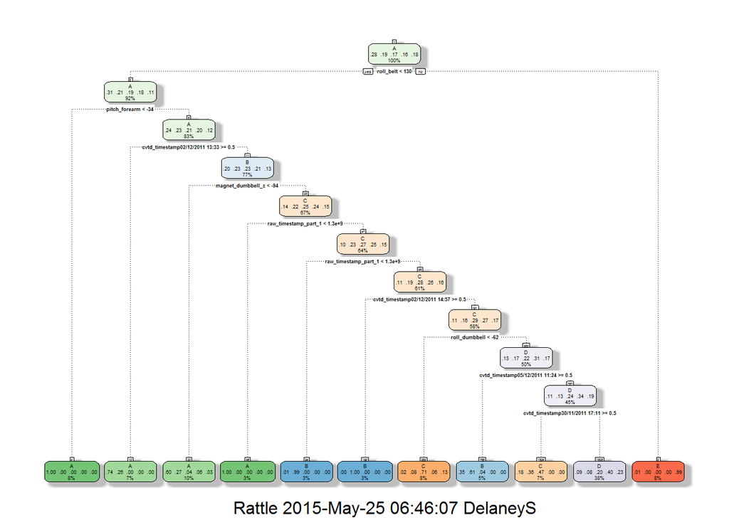

```r
fancyRpartPlot(rpFit$finalModel)
```

This model is now used to predict the values in the testing set we split off earlier.

```r
## let's try it on the testing data
predictedValues <- predict(rpFit,newdata=testingSet)

## so how did we do
confusionMatrix(predictedValues, testingSet$classe)
```

```
## Confusion Matrix and Statistics
##
##           Reference
## Prediction    A    B    C    D    E
##          A 1640  356   39   44   14
##          B  155  669   16    0    0
##          C  139  243  724   28   74
##          D  292  250  589 1214  713
##          E    6    0    0    0  641
##
## Overall Statistics
##
##                Accuracy : 0.623
##                  95% CI : (0.6122, 0.6337)
##     No Information Rate : 0.2845
##     P-Value [Acc > NIR] : < 2.2e-16
##
##                   Kappa : 0.5273
##  Mcnemar's Test P-Value : NA
##
## Statistics by Class:
##
##                      Class: A Class: B Class: C Class: D Class: E
## Sensitivity            0.7348  0.44071  0.52924   0.9440  0.44452
## Specificity            0.9193  0.97298  0.92529   0.7189  0.99906
## Pos Pred Value         0.7836  0.79643  0.59934   0.3970  0.99073
## Neg Pred Value         0.8971  0.87882  0.90298   0.9850  0.88873
## Prevalence             0.2845  0.19347  0.17436   0.1639  0.18379
## Detection Rate         0.2090  0.08527  0.09228   0.1547  0.08170
## Detection Prevalence   0.2668  0.10706  0.15396   0.3898  0.08246
## Balanced Accuracy      0.8270  0.70684  0.72726   0.8315  0.72179
```

The results, whilst better than simply guessing, are still too low be of practical use.

An alternate modelling approach is now applied. The use of random forests in an attempt to increase the accuracy.

In order to speed execution, the number of trees in the random forest was limited to 600. Validating the trace output, we can see that no relevant improvement in model performance occurs after about 500 trees.

```r
rfFit <- randomForest(classe ~., data=finalTrainingSet, mtry=3, ntree=600, prox=TRUE, do.trace=25)
```

```
## ntree      OOB      1      2      3      4      5
##    25:   0.84%  0.15%  1.45%  1.36%  1.50%  0.18%
##    50:   0.37%  0.06%  0.44%  0.63%  0.78%  0.18%
##    75:   0.32%  0.09%  0.22%  0.54%  0.73%  0.23%
##   100:   0.25%  0.00%  0.18%  0.54%  0.67%  0.09%
##   125:   0.26%  0.00%  0.09%  0.58%  0.73%  0.14%
##   150:   0.25%  0.00%  0.09%  0.54%  0.78%  0.09%
##   175:   0.24%  0.00%  0.09%  0.49%  0.73%  0.09%
##   200:   0.25%  0.00%  0.09%  0.54%  0.78%  0.09%
##   225:   0.23%  0.00%  0.09%  0.49%  0.67%  0.09%
##   250:   0.23%  0.00%  0.09%  0.49%  0.67%  0.09%
##   275:   0.22%  0.00%  0.09%  0.49%  0.62%  0.09%
##   300:   0.23%  0.00%  0.09%  0.49%  0.67%  0.09%
##   325:   0.22%  0.00%  0.09%  0.49%  0.62%  0.09%
##   350:   0.20%  0.00%  0.09%  0.49%  0.52%  0.09%
##   375:   0.20%  0.00%  0.09%  0.49%  0.52%  0.09%
##   400:   0.22%  0.03%  0.09%  0.49%  0.57%  0.09%
##   425:   0.20%  0.00%  0.09%  0.54%  0.47%  0.09%
##   450:   0.21%  0.00%  0.09%  0.58%  0.47%  0.09%
##   475:   0.20%  0.00%  0.09%  0.54%  0.47%  0.09%
##   500:   0.21%  0.00%  0.09%  0.58%  0.47%  0.09%
##   525:   0.23%  0.03%  0.09%  0.54%  0.57%  0.09%
##   550:   0.21%  0.00%  0.09%  0.54%  0.52%  0.09%
##   575:   0.21%  0.00%  0.09%  0.54%  0.52%  0.09%
##   600:   0.21%  0.00%  0.09%  0.54%  0.52%  0.09%
```

```r
rfFit
```

```
##
## Call:
##  randomForest(formula = classe ~ ., data = finalTrainingSet, mtry = 3,      ntree = 600, prox = TRUE, do.trace = 25)
##                Type of random forest: classification
##                      Number of trees: 600
## No. of variables tried at each split: 3
##
##         OOB estimate of  error rate: 0.21%
## Confusion matrix:
##      A    B    C    D    E  class.error
## A 3348    0    0    0    0 0.0000000000
## B    2 2277    0    0    0 0.0008775779
## C    0   10 2043    1    0 0.0053554041
## D    0    0   10 1920    0 0.0051813472
## E    0    0    0    2 2163 0.0009237875
```

Evaluating its results gives:

```r
predictedValues <- predict(rfFit,newdata=testingSet)
confusionMatrix(predictedValues, testingSet$classe)
```

```
## Confusion Matrix and Statistics
##
##           Reference
## Prediction    A    B    C    D    E
##          A 2230    0    0    0    0
##          B    2 1518    9    0    0
##          C    0    0 1359    2    0
##          D    0    0    0 1283    5
##          E    0    0    0    1 1437
##
## Overall Statistics
##
##                Accuracy : 0.9976
##                  95% CI : (0.9962, 0.9985)
##     No Information Rate : 0.2845
##     P-Value [Acc > NIR] : < 2.2e-16
##
##                   Kappa : 0.9969
##  Mcnemar's Test P-Value : NA
##
## Statistics by Class:
##
##                      Class: A Class: B Class: C Class: D Class: E
## Sensitivity            0.9991   1.0000   0.9934   0.9977   0.9965
## Specificity            1.0000   0.9983   0.9997   0.9992   0.9998
## Pos Pred Value         1.0000   0.9928   0.9985   0.9961   0.9993
## Neg Pred Value         0.9996   1.0000   0.9986   0.9995   0.9992
## Prevalence             0.2845   0.1935   0.1744   0.1639   0.1838
## Detection Rate         0.2842   0.1935   0.1732   0.1635   0.1832
## Detection Prevalence   0.2842   0.1949   0.1735   0.1642   0.1833
## Balanced Accuracy      0.9996   0.9991   0.9966   0.9985   0.9982
```

This is a much more useful result, giving an out of sample of error of under 0.5%

As such, this model will be used to predict the values from the held back quiz set.